# Perfil COMEX Brasil

Luiz Antonio Gouveia & Josue Araujo

26/10/2018

```r
knitr::opts_chunk$set(echo = FALSE)
```

## Objeto

O objeto de análise neste relatório é a corrente de comércio exterior brasileiro, ou seja, as atividades de exportação e importação do setor produtivo nacional.

A partir deste enquadramento, foram coletados e analisados dados sobre os principais produtos exportados e importados, origens e destinos (países parceiros) dos produtos comercializados e a evolução da balança comercial brasileira nos últimos 20 (vinte) anos.

## Objetivos

Este relatório analítico buscou responder as seguintes questões:

- Como evoluiu a balança comercial brasileira nos últimos 20 anos?
- Quais são os principais produtos exportados e importados pelo Brasil?
- Quais são os principais países parceiros do comércio exterior brasileiro?

## Contexto

De acordo como o FMI, o Brasil figurou em nono lugar no ranking das maiores economias do mundo em 2018. Além de grande, a economia brasileira é razoavelmente diversificada e sofisticada tecnologicamente.

A despeito dessas características positivas, a participação do nosso país no comércio mundial é ínfima, alcançando apenas 1,1% da movimentação global de produtos.

Como o Brasil se insere na corrente de comércio global? Quem são seus parceiros e quais so principais produtos comercializados?

São estas perguntas que o presente estudo pretende responder.

## Método

Todos os dados utilizados na presente análise foram coletados do portal de dados e estatísticas de comércio exterior do Ministério da Indústria, Comércio Exterior e Serviços - MDIC - (“http://comexstat.mdic.gov.br/pt/home”).

Foram acessadas as bases de dados de exportação e importação de produtos, de municípios exportadores/importadores e, por fim, as Tabelas de Correlações de Códigos e Classificações de produtos e países.

Inicialmente, as bases de dados foram inspecionadas e foram descartadas aquelas variáveis que não interessavam à análise. Em seguida, foram gerados diversos dataframes para efeito de produção de tabelas e gráficos.

Os dados foram organizados em torno de 3 (três) blocos de informação, quais sejam: balança comercial, principais produtos exportados/importados (pauta de produtos) e principais parceiros comerciais.

A análise estatística dos dados limitou-se à descrição simples dos dados coletados e à explicação dos gráficos gerados.

### Carregando os pacotes requeridos

#### Carregando as bases de dados

```r
Sys.setlocale("LC_ALL","pt_BR.UTF-8")
```

```
## [1] "pt_BR.UTF-8/pt_BR.UTF-8/pt_BR.UTF-8/C/pt_BR.UTF-8/C"
```

```r
# Base de dados de exportação
brasil_expo <- read.csv("/Users/MAC/Documents/AMBIENTE R/Curso-Enap-Dados-Secundarios/Curso Enap Dados Secundarios/Projeto Luiz e Josue/Base de dados detalhada por NCM/EXP_COMPLETA.csv", sep = ";", encoding = "latin1")


# Base de dados de importação
brasil_impo <- read.csv("/Users/MAC/Documents/AMBIENTE R/Curso-Enap-Dados-Secundarios/Curso Enap Dados Secundarios/Projeto Luiz e Josue/Base de dados detalhada por NCM/IMP_COMPLETA.csv", sep = ";", encoding = "latin1")


# Bases de dados auxiliares

metricas <- read.csv("http://www.mdic.gov.br/balanca/bd/tabelas/NCM_UNIDADE.csv", sep = ";", encoding = "latin1")

ncm <- read.csv("http://www.mdic.gov.br/balanca/bd/tabelas/NCM.csv", sep = ";", encoding = "latin1")

paises <- read.csv("http://www.mdic.gov.br/balanca/bd/tabelas/PAIS.csv", sep = ";", encoding = "latin1")

municipios <- read.csv("http://www.mdic.gov.br/balanca/bd/tabelas/UF_MUN.csv", sep = ";", encoding = "latin1")

estados <- read.csv("http://www.mdic.gov.br/balanca/bd/tabelas/UF.csv", sep = ";", encoding = "latin1")

via_de_transporte <- read.csv("http://www.mdic.gov.br/balanca/bd/tabelas/VIA.csv", sep = ";", encoding = "latin1")

categorias_produtos <- read.csv("http://www.mdic.gov.br/balanca/bd/tabelas/NCM_CGCE.csv", sep = ";", encoding = "latin1")
```

### Limpando as bases de dados

```r
brasil_expo_alt <- brasil_expo %>%
  filter(CO_ANO < 2018) %>%
  select(-CO_URF, -QT_ESTAT)

brasil_impo_alt <- brasil_impo %>%
  filter(CO_ANO < 2018) %>%
  select(-CO_URF, -QT_ESTAT)
```

### Manipulando os dados

```r
# agrupando exportações por ano
expo_ano <- brasil_expo_alt %>%
  group_by(CO_ANO) %>%
  summarise(Total_expo = sum(VL_FOB))

# agrupando importações por ano
impo_ano <- brasil_impo_alt %>%
  group_by(CO_ANO) %>%
  summarise(Total_impo = sum(as.numeric(VL_FOB)))
```

```r
# agrupando exportações por produto
expo_produto <- brasil_expo_alt %>%
  group_by(CO_NCM) %>%
  summarise(Total_expo = sum(VL_FOB)/10^9) %>%
             arrange(desc(Total_expo))

# Identificando os nomes dos produtos exportados
expo_produto <- left_join(expo_produto, ncm %>%
                             select(CO_NCM, NO_NCM_POR), by = c("CO_NCM" = "CO_NCM"))

# agrupando exportações por produto no ano de 2017
expo_produto_2017 <- brasil_expo_alt %>%
  group_by(CO_NCM) %>%
  filter(CO_ANO == 2017) %>%
  summarise(Total_expo = sum(VL_FOB)/10^9) %>%
             arrange(desc(Total_expo))

# Identificando os nomes dos produtos exportados 2017
expo_produto_2017 <- left_join(expo_produto_2017, ncm %>%
                             select(CO_NCM, NO_NCM_POR), by = c("CO_NCM" = "CO_NCM")) %>%
  mutate(US_billions = round(expo_produto_2017$Total_expo, digits = 2))

# Rankeando os dez principais produtos exportados em 2017
principais_export_2017 <- dplyr::slice(expo_produto_2017, 1:10) %>%
  separate(NO_NCM_POR, sep = ',', extra = 'drop', fill = 'right', into = c('NO_NCM_POR', 's2'))
```

```r
# agrupando importações por produto
impo_produto <- brasil_impo_alt %>%
  group_by(CO_NCM) %>%
  summarise(Total_impo = sum(as.numeric(VL_FOB)/10^9)) %>%
             arrange(desc(Total_impo))

# Identificando os nomes dos produtos importados
impo_produto <- left_join(impo_produto, ncm %>%
                             select(CO_NCM, NO_NCM_POR), by = c("CO_NCM" = "CO_NCM"))

# agrupando importações por produto no ano de 2017
impo_produto_2017 <- brasil_impo_alt %>%
  group_by(CO_NCM) %>%
  filter(CO_ANO == 2017) %>%
  summarise(Total_impo = sum(VL_FOB)/10^9) %>%
             arrange(desc(Total_impo))

# Identificando os nomes dos produtos importados 2017
impo_produto_2017 <- left_join(impo_produto_2017, ncm %>%
                             select(CO_NCM, NO_NCM_POR), by = c("CO_NCM" = "CO_NCM")) %>%
  mutate(US_billions = round(impo_produto_2017$Total_impo, digits = 2))


# Rankeando os dez principais produtos importados em 2017
principais_import_2017 <- dplyr::slice(impo_produto_2017, 1:10) %>%
  separate(NO_NCM_POR, sep = ',', extra = 'drop', fill = 'right', into = c('NO_NCM_POR', 's2'))
```

```r
# agrupando exportações por país de destino
expo_país <- brasil_expo_alt %>%
  group_by(CO_PAIS) %>%
  summarise(Total_expo = sum(VL_FOB)/10^9) %>%
             arrange(desc(Total_expo))

# Identificando os nomes dos países de destino
expo_país <- left_join(expo_país, paises %>%
                             select(CO_PAIS, NO_PAIS), by = c("CO_PAIS" = "CO_PAIS"))

# agrupando exportações por país de destino no ano de 2017
expo_pais_2017 <- brasil_expo_alt %>%
  group_by(CO_PAIS) %>%
  filter(CO_ANO == 2017) %>%
  summarise(Total_expo = sum(VL_FOB)/10^9) %>%
             arrange(desc(Total_expo))

# Identificando os nomes dos paises de destino 2017
expo_pais_2017 <- left_join(expo_pais_2017, paises %>%
                             select(CO_PAIS, NO_PAIS), by = c("CO_PAIS" = "CO_PAIS")) %>%
  mutate(US_billions = round(expo_pais_2017$Total_expo, digits = 2))

# Rankeando os dez principais destinos em 2017
expo_pais_2017 <- dplyr::slice(expo_pais_2017, 1:10)
```

```r
# agrupando importações por país de origem
impo_país <- brasil_impo_alt %>%
  group_by(CO_PAIS) %>%
  summarise(Total_impo = sum(as.numeric(VL_FOB))/10^9) %>%
             arrange(desc(Total_impo))

# Identificando os nomes dos países de origem
impo_país <- left_join(impo_país, paises %>%
                             select(CO_PAIS, NO_PAIS), by = c("CO_PAIS" = "CO_PAIS"))

# agrupando importações por país de origem no ano de 2017
impo_pais_2017 <- brasil_impo_alt %>%
  group_by(CO_PAIS) %>%
  filter(CO_ANO == 2017) %>%
  summarise(Total_impo = sum(as.numeric(VL_FOB))/10^9) %>%
             arrange(desc(Total_impo))

# Identificando os nomes dos paises de origem 2017
impo_pais_2017 <- left_join(impo_pais_2017, paises %>%
                             select(CO_PAIS, NO_PAIS), by = c("CO_PAIS" = "CO_PAIS")) %>%
  mutate(US_billions = round(impo_pais_2017$Total_impo, digits = 2))

# Rankeando as dez principais origens em 2017
impo_pais_2017 <- dplyr::slice(impo_pais_2017, 1:10)
```

```r
# Calculando o saldo da balança comercial brasileira

saldo_balanca <- merge(expo_ano,impo_ano,by="CO_ANO") %>%
  mutate(Saldo = expo_ano$Total_expo - impo_ano$Total_impo)
```

### Visualizando os dados

#### Gráficos/tabelas

```r
# Resumo das estatísticas da balança comercial
summary(saldo_balanca)
```

```
##      CO_ANO       Total_expo          Total_impo
##  Min.   :1997   Min.   :4.795e+10   Min.   :4.714e+10
##  1st Qu.:2002   1st Qu.:6.029e+10   1st Qu.:5.760e+10
##  Median :2007   Median :1.529e+11   Median :1.205e+11
##  Mean   :2007   Mean   :1.440e+11   Mean   :1.229e+11
##  3rd Qu.:2012   3rd Qu.:2.018e+11   3rd Qu.:1.731e+11
##  Max.   :2017   Max.   :2.559e+11   Max.   :2.397e+11
##      Saldo
##  Min.   :-6.537e+09
##  1st Qu.: 2.286e+09
##  Median : 2.001e+10
##  Mean   : 2.102e+10
##  3rd Qu.: 3.359e+10
##  Max.   : 6.699e+10
```

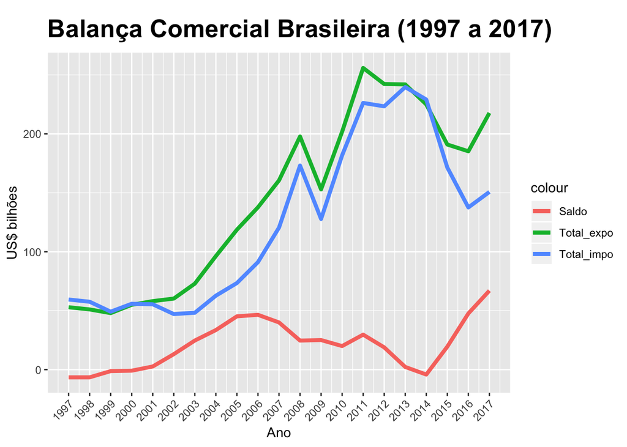

```r
# Série histórica da balança comercial brasileira

ggplot(data = saldo_balanca, aes(CO_ANO)) +
  geom_line(aes(y = Total_expo/10^9, color = "Total_expo"), size = 1.5) +
  geom_line(aes(y = Total_impo/10^9, color = "Total_impo"), size = 1.5) +
  geom_line(aes(y = Saldo/10^9, color = "Saldo"), size = 1.5) +
              xlab("Ano") +
  ylab("US$ bilhões") +
  ggtitle("Balança Comercial Brasileira (1997 a 2017)") +
  theme(axis.text.x = element_text(angle = 45, vjust = 1, hjust = 1), plot.title = element_text(color="black", size=20, face="bold", margin = margin(10, 100, 10, 1))) +
  scale_x_continuous(breaks = c(1997:2017), labels = c(as.character(1997:2017)))
```

```r
# Resumo das estatísticas dos produtos exportados em 2017
summary(principais_export_2017)
```

```
##      CO_NCM           Total_expo      NO_NCM_POR             s2
##  Min.   : 2023000   Min.   : 4.039   Length:10          Length:10
##  1st Qu.: 9273085   1st Qu.: 4.574   Class :character   Class :character
##  Median :14515200   Median : 5.211   Mode  :character   Mode  :character
##  Mean   :17536902   Mean   : 9.607
##  3rd Qu.:25268348   3rd Qu.:14.729
##  Max.   :47032900   Max.   :25.712
##   US_billions
##  Min.   : 4.040
##  1st Qu.: 4.577
##  Median : 5.210
##  Mean   : 9.607
##  3rd Qu.:14.725
##  Max.   :25.710
```

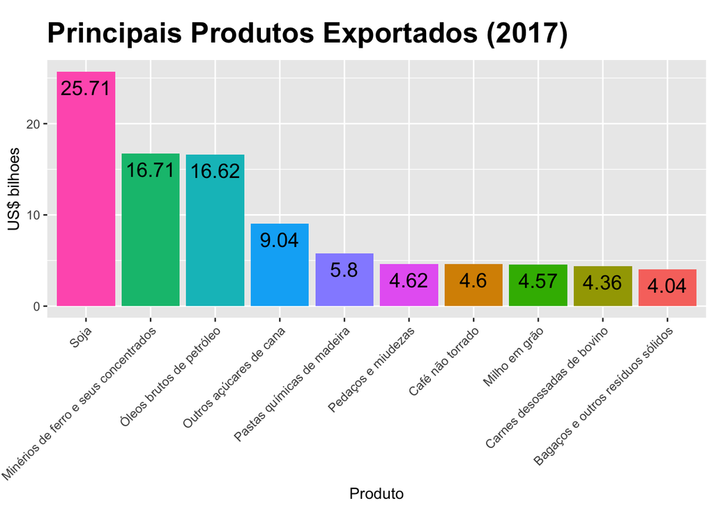

```r
# Principais produtos exportados em 2017

ggplot() +
  geom_col(aes(y = US_billions, x = reorder(NO_NCM_POR, -US_billions), fill = NO_NCM_POR), data = principais_export_2017) +
  xlab("Produto") +
  ylab("US$ bilhoes") +
  ggtitle("Principais Produtos Exportados (2017)") +
  theme(plot.title = element_text(color="black", size=20, face="bold", margin = margin(10, 100, 10, 1))) +
  theme(axis.text.x = element_text(angle = 45, vjust = 1, hjust = 1), legend.position = "none") +
  geom_text(data = principais_export_2017, aes(y = US_billions, x = NO_NCM_POR, label = US_billions), vjust = 1.6, size = 5)
```

```r
# Resumo das estatísticas dos produtos importados em 2017
summary(principais_import_2017)
```

```
##      CO_NCM           Total_impo     NO_NCM_POR             s2
##  Min.   :10019900   Min.   :1.148   Length:10          Length:10
##  1st Qu.:28089328   1st Qu.:1.200   Class :character   Class :character
##  Median :58176510   Median :1.265   Mode  :character   Mode  :character
##  Mean   :55818899   Mean   :1.413
##  3rd Qu.:86630012   3rd Qu.:1.668
##  Max.   :87084080   Max.   :1.908
##   US_billions
##  Min.   :1.150
##  1st Qu.:1.200
##  Median :1.265
##  Mean   :1.414
##  3rd Qu.:1.667
##  Max.   :1.910
```

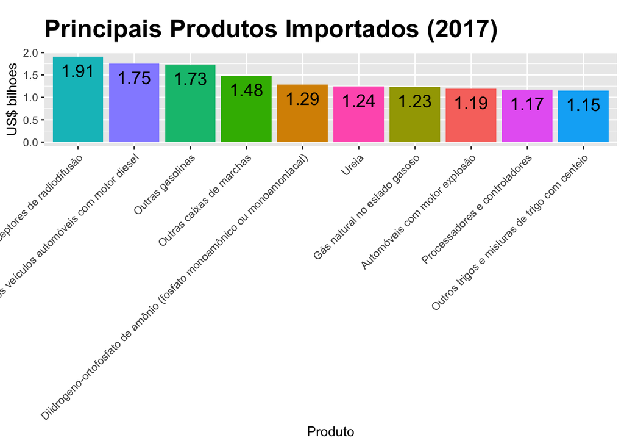

```r
# Principais produtos importados em 2017

ggplot() +
  geom_col(aes(y = US_billions, x = reorder(NO_NCM_POR, -US_billions), fill = NO_NCM_POR), data = principais_import_2017) +
  xlab("Produto") +
  ylab("US$ bilhoes") +
  ggtitle("Principais Produtos Importados (2017)") +
  theme(plot.title = element_text(color="black", size=20, face="bold", margin = margin(10, 100, 10, 1))) +
  theme(axis.text.x = element_text(angle = 45, vjust = 1, hjust = 1), legend.position = "none") +
  geom_text(data = principais_import_2017, aes(y = US_billions, x = NO_NCM_POR, label = US_billions), vjust = 1.6, size = 5)
```

```r
# Resumo das estatísticas dos principais destinos em 2017
summary(principais_export_2017)
```

```
##      CO_NCM           Total_expo      NO_NCM_POR             s2
##  Min.   : 2023000   Min.   : 4.039   Length:10          Length:10
##  1st Qu.: 9273085   1st Qu.: 4.574   Class :character   Class :character
##  Median :14515200   Median : 5.211   Mode  :character   Mode  :character
##  Mean   :17536902   Mean   : 9.607
##  3rd Qu.:25268348   3rd Qu.:14.729
##  Max.   :47032900   Max.   :25.712
##   US_billions
##  Min.   : 4.040
##  1st Qu.: 4.577
##  Median : 5.210
##  Mean   : 9.607
##  3rd Qu.:14.725
##  Max.   :25.710
```

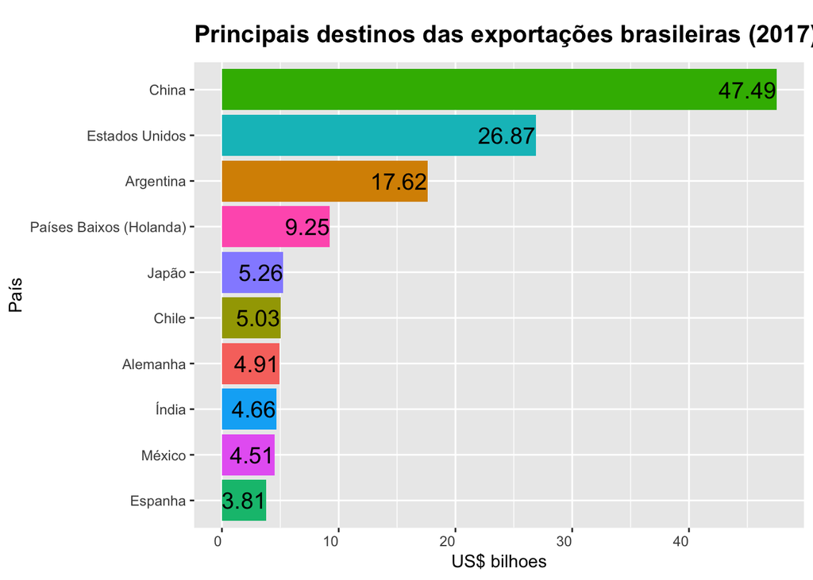

```r
# Principais destinos em 2017

ggplot() +
  geom_col(aes(y = US_billions, x = reorder(NO_PAIS, +US_billions), fill = NO_PAIS), data = expo_pais_2017) +
  ylab("US$ bilhoes") +
  xlab("País") +
  coord_flip() +
  ggtitle("Principais destinos das exportações brasileiras (2017)") +
  theme(plot.title = element_text(color="black", size=15, face="bold", margin = margin(10, 100, 10, 1))) +
  theme(axis.text.x = element_text(vjust = 1, hjust = 1), legend.position = "none") +
  geom_text(data = expo_pais_2017, aes(y = US_billions, x = NO_PAIS, label = US_billions), vjust = 0.5, hjust = 1.0, size = 5)
```

```r
# Resumo das estatísticas das principais origens em 2017
summary(principais_import_2017)
```

```
##      CO_NCM           Total_impo     NO_NCM_POR             s2
##  Min.   :10019900   Min.   :1.148   Length:10          Length:10
##  1st Qu.:28089328   1st Qu.:1.200   Class :character   Class :character
##  Median :58176510   Median :1.265   Mode  :character   Mode  :character
##  Mean   :55818899   Mean   :1.413
##  3rd Qu.:86630012   3rd Qu.:1.668
##  Max.   :87084080   Max.   :1.908
##   US_billions
##  Min.   :1.150
##  1st Qu.:1.200
##  Median :1.265
##  Mean   :1.414
##  3rd Qu.:1.667
##  Max.   :1.910
```

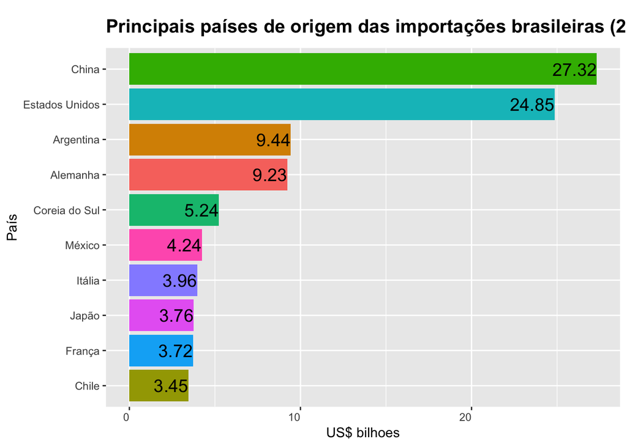

```r
# Principais origens em 2017

ggplot() +
  geom_col(aes(y = US_billions, x = reorder(NO_PAIS, +US_billions), fill = NO_PAIS), data = impo_pais_2017) +
  ylab("US$ bilhoes") +
  xlab("País") +
  coord_flip() +
  ggtitle("Principais países de origem das importações brasileiras (2017)") +
  theme(plot.title = element_text(color="black", size=15, face="bold", margin = margin(10, 100, 10, 1))) +
  theme(axis.text.x = element_text(vjust = 1, hjust = 1), legend.position = "none") +
  geom_text(data = impo_pais_2017, aes(y = US_billions, x = NO_PAIS, label = US_billions), vjust = 0.5, hjust = 1.0, size = 5)
```

## Conclusões

O Brail é bastante dependente da exportação de produtos primários, como minério de ferro e soja. Estes produtos apresentam baixo valor agregado, isto é, rendem pouco por tonelada produzida.

Com efeito, os três primeiros produtos da pauta de exportação nacional são a soja, o minério de ferro e o petróleo bruto. O Brasil, assim, tem grande dificuldade de agregar valor aos seus produtos.

Por outro lado, os três principais produtos da nossa pauta de importação são os aparelhos receptores de rádiodifusão (televisores), veículos automotivos e combustíveis.

Os principais destinos das exportações brasileiras são China, EUA e Argentina. Estes mesmos países são, também, os maiores exportadores de produtos para o Brasil.

Do ponto de vista de série histórica da Balança Comercial Brasileira ao longo dos últimos 20 (vinte) anos, destacamos que o Plano Real impulsionou a entrada de produtos estrangeiros no mercado brasileiro, via apreciação do câmbio, o que provocou a queda o preço dos produtos importados.

A partir de 2001, a balança comercial brasileira começou a apresentar superávits. Neste período foi adotado o câmbio flutuante, que desvalorizou o real perante o dólar, aumentando o volume de exportações brasileiras. Ainda, nosso país tornou-se um Global Trader, isto é, passou a negociar com todo o mundo, aumentando a área de alcance de suas mercadorias.

Nos últimos anos, as crises econômica e política, relacionadas com o impeachment da presidente Dilma Rousseff, tem, de certa forma, auxiliado na estabilização do superávit brasileiro. Com a recessão, as compras do exterior tendem a diminuir. Podemos citar, ainda, a depreciação do câmbio, diminuindo o preço do produto brasileiro no exterior.